# Bootstrapping Confidence Intervals

# Learning Objective

- S-IC.B.4: Use data from a sample survey to estimate a population mean or proportion; develop a margin of error through the use of simulation models for random sampling.

# Confidence Interval

- A [confidence interval](https://en.wikipedia.org/wiki/Confidence_interval) is used to express uncertainty about a population mean (or proportion).
- Imagine repeating the process of:
  - Gathering a simple random sample,
  - calculating the sample mean ($\bar{x}$) and sample standard deviation ($s$),
  - calculating a confidence interval (lower boundary and upper boundary) using:
    - bootstrapping (if $n$ is small and distribution is maybe not bell shaped) or
    - $\bar{x}\pm\frac{2s}{\sqrt{n}}$ if $n$ is sufficiently large or we know the population is bell shaped.
- The true population mean ($\mu$) will be in the confidence interval 95% of the time.
- [Misinterpretations are common](https://en.wikipedia.org/wiki/Confidence_interval#Common_misunderstandings), even among professionals.

# Bootstrapping

- The most robust approach to calculating confidence intervals is with repeated resampling.
- The steps are *very* similar to how we got intervals of typical means. The key new step is that we resample, with replacement, from the actual sample.
- In a spreadsheet, we will resample with replacement by using the [`=INDEX()` function](https://support.google.com/docs/answer/3098242?hl=en) mixed with a `RANDBETWEEN()`.
- Process:
  - Get a sample of data.
  - Resample with replacement 1000 times.
  - For each resample, calculate a mean.
  - Find the 2.5th percentile and the 97.5th percentile. These are the boundaries of the 95% confidence interval.
  - Calculate the half-width (radius) of the interval. This is your margin of error.
- Let’s look at an example of resampling on the next two slides.

# Example of resampling

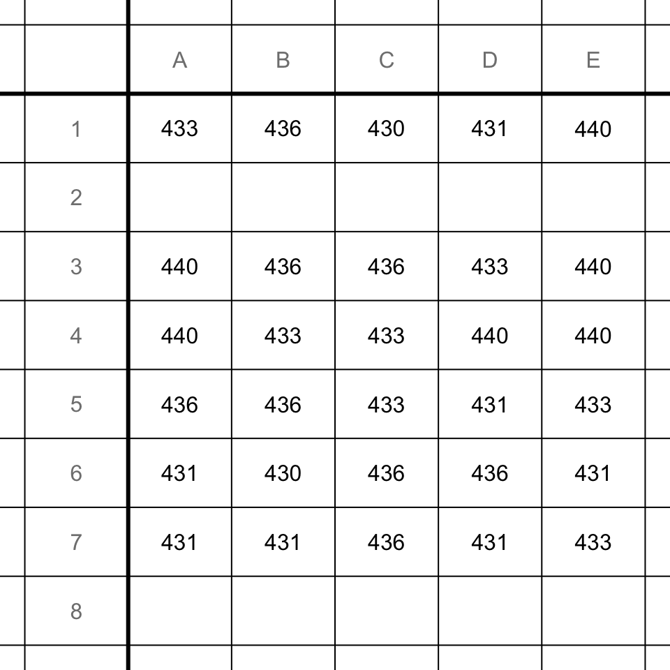

- The first row is our original sample.
- The other rows are generated by sampling from the first row, **with replacement**.
- Notice that even though the first row has no repeats, the other rows do!

# Example of resampling

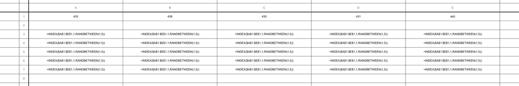

# Practice bootstrapping

- https://chadworley.github.io/a2/u02/outhtml/05_resample_mean_ME.html
- https://bart.instructure.com/courses/1314/quizzes/2315